# Noter - Lektion 7

Johan Ejstrud

2022-04-27

## Basic maps [(02:24)](https://www.youtube.com/watch?v=Srg3DZu49S4&t=144s)

```r
library(tidyverse)

kl <-
  map_data("world", "greenland") %>%
  as_tibble()

kl
```

```
## # A tibble: 2,240 x 6
##     long   lat group order region    subregion
##    <dbl> <dbl> <dbl> <int> <chr>     <chr>
##  1 -46.3  60.8     1     1 Greenland 1
##  2 -46.4  60.7     1     2 Greenland 1
##  3 -46.5  60.7     1     3 Greenland 1
##  4 -46.6  60.7     1     4 Greenland 1
##  5 -46.7  60.8     1     5 Greenland 1
##  6 -46.8  60.8     1     6 Greenland 1
##  7 -46.8  60.8     1     7 Greenland 1
##  8 -46.4  60.9     1     8 Greenland 1
##  9 -46.2  60.9     1     9 Greenland 1
## 10 -46.2  60.9     1    10 Greenland 1
## # ... with 2,230 more rows
```

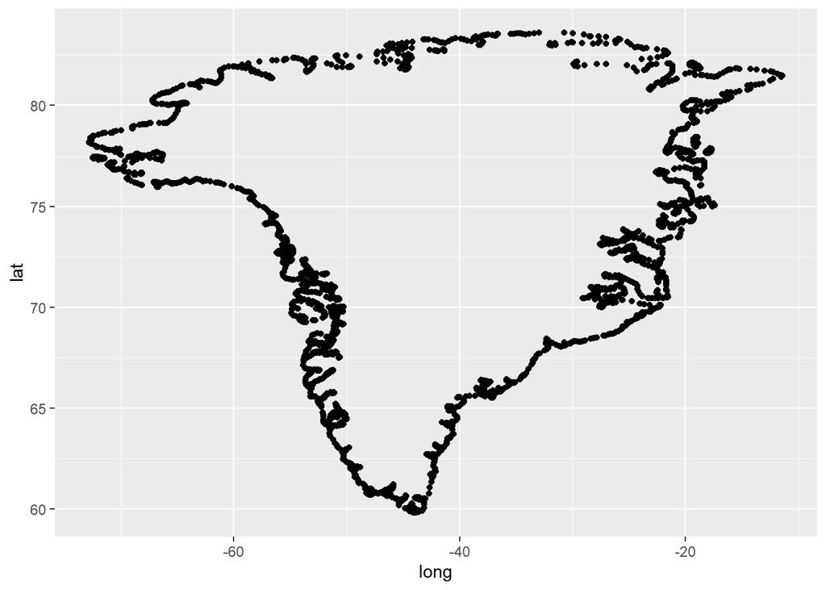

```r
ggplot(kl, aes(long, lat)) +
  geom_point()
```

### Fix coordinate system [(05:59)](https://www.youtube.com/watch?v=Srg3DZu49S4&t=359s)

- `coord_quickmap()` sets the same scale for longitude and latitude. (This is a fast approximation of the Mercator projection.)

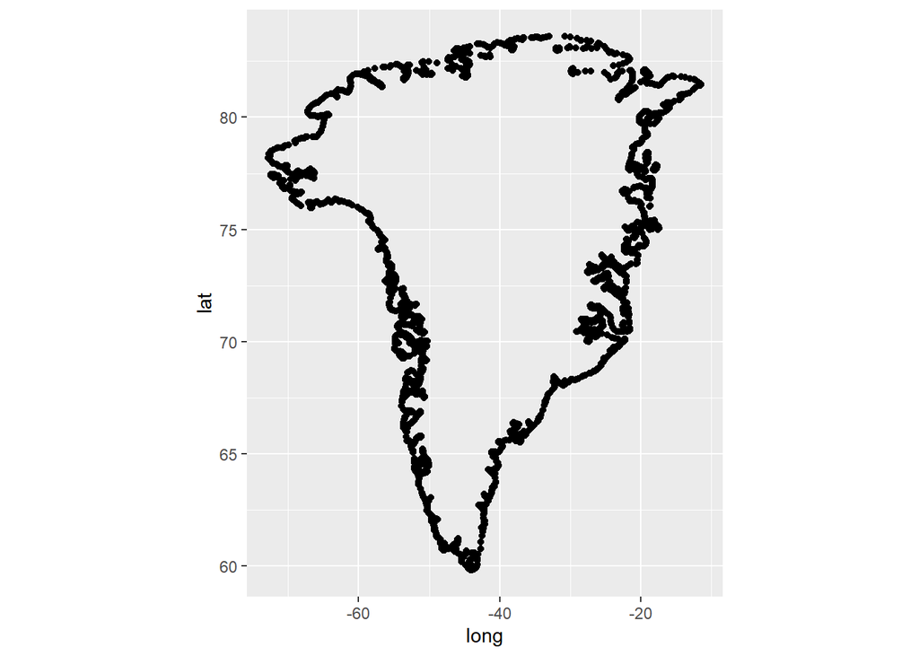

```r
ggplot(kl, aes(long, lat)) +
  geom_point() +
  coord_quickmap()
```

- `geom_polygon()` draws maps as areas. `group` ensures that the polygons are properly closed.

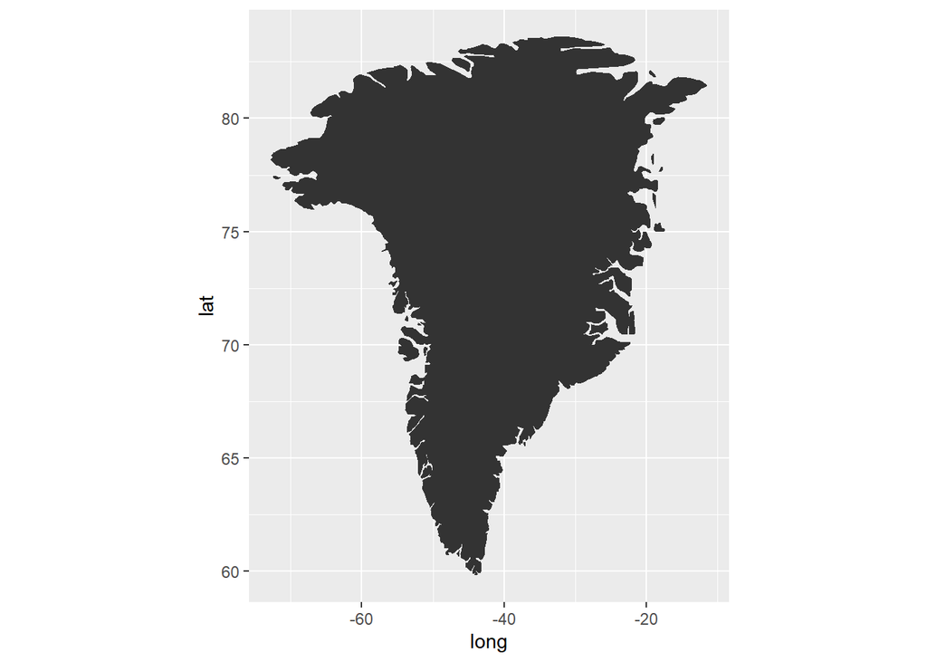

```r
ggplot(kl, aes(long, lat, group = group)) +
  geom_polygon() +
  coord_quickmap()
```

### Zoom [(07:00)](https://www.youtube.com/watch?v=Srg3DZu49S4&t=420s)

- Use `xlim` and `ylim` to zoom.

(The top fjord is Kangerlussuaq; the bottom fjord is Nuup Kangerlua.)

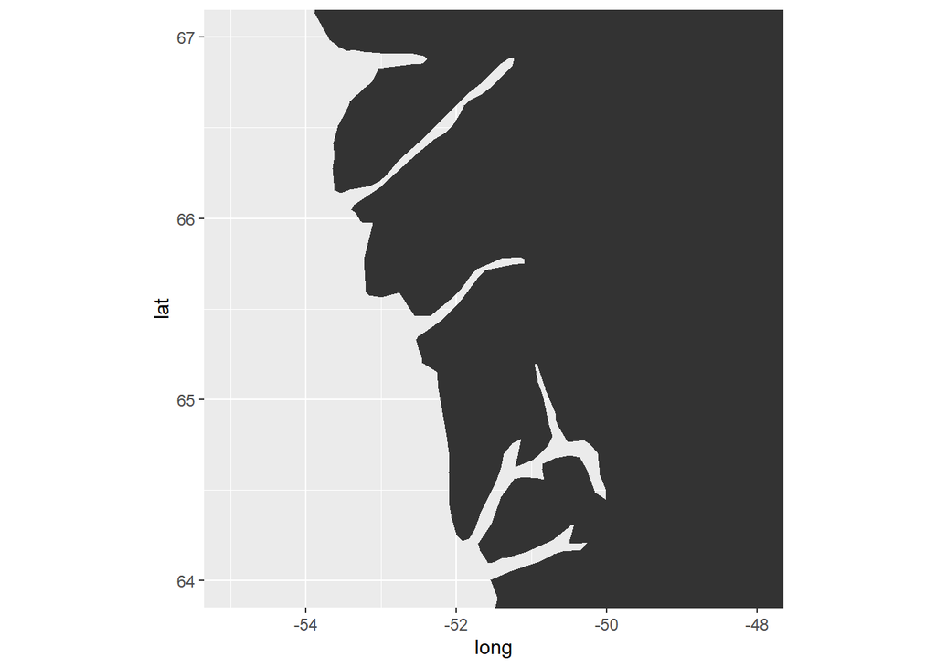

```r
ggplot(kl, aes(long, lat, group = group)) +
  geom_polygon() +
  coord_quickmap(xlim = c(-55, -48), ylim = c(64, 67))
```

```r
# Store zoom values for later use
nuuk.x <- c(-55, -48)
nuuk.y <- c( 64,  67)
nuuk.close.x <- c(-52.7, -49.6)
nuuk.close.y <- c( 63.8,  65.2)
```

## Simple features [(08:05)](https://www.youtube.com/watch?v=Srg3DZu49S4&t=485s)

- More complex map data is usually encoded as *simple features* which requires the package ‘sf’.

```r
library(sf)
```

- The package ‘rnaturalearth’ contains simple feature data from https://www.naturalearthdata.com/ .

sf data contains various metadata which makes it complex to look at.

```r
library(rnaturalearth)

kl_sf <- ne_countries(country = "greenland",
                      returnclass = "sf",
                      scale = "medium")

kl_sf
```

```
## Simple feature collection with 1 feature and 63 fields
## Geometry type: MULTIPOLYGON
## Dimension:     XY
## Bounding box:  xmin: -72.81807 ymin: 59.81548 xmax: -11.42554 ymax: 83.59961
## CRS:           +proj=longlat +datum=WGS84 +no_defs +ellps=WGS84 +towgs84=0,0,0
##    scalerank      featurecla labelrank sovereignt sov_a3 adm0_dif level    type
## 86         1 Admin-0 country         3    Denmark    DN1        1     2 Country
##        admin adm0_a3 geou_dif   geounit gu_a3 su_dif   subunit su_a3 brk_diff
## 86 Greenland     GRL        0 Greenland   GRL      0 Greenland   GRL        0
##         name name_long brk_a3  brk_name brk_group abbrev postal formal_en
## 86 Greenland Greenland    GRL Greenland      <NA> Grlnd.     GL Greenland
##    formal_fr note_adm0 note_brk name_sort name_alt mapcolor7 mapcolor8
## 86      <NA>      Den.     <NA> Greenland     <NA>         4         1
##    mapcolor9 mapcolor13 pop_est gdp_md_est pop_year lastcensus gdp_year
## 86         3         12   57600       1100       NA       2010       NA
##                       economy              income_grp wikipedia fips_10 iso_a2
## 86 2. Developed region: nonG7 2. High income: nonOECD        NA    <NA>     GL
##    iso_a3 iso_n3 un_a3 wb_a2 wb_a3 woe_id adm0_a3_is adm0_a3_us adm0_a3_un
## 86    GRL    304   304    GL   GRL     NA        GRL        GRL         NA
##    adm0_a3_wb     continent region_un        subregion             region_wb
## 86         NA North America  Americas Northern America Europe & Central Asia
##    name_len long_len abbrev_len tiny homepart                       geometry
## 86        9        9          6   NA       NA MULTIPOLYGON (((-51.33887 6...
```

- Simple features are plotted with `geom_sf()`. (We don’t even need to specify aesthetics.)

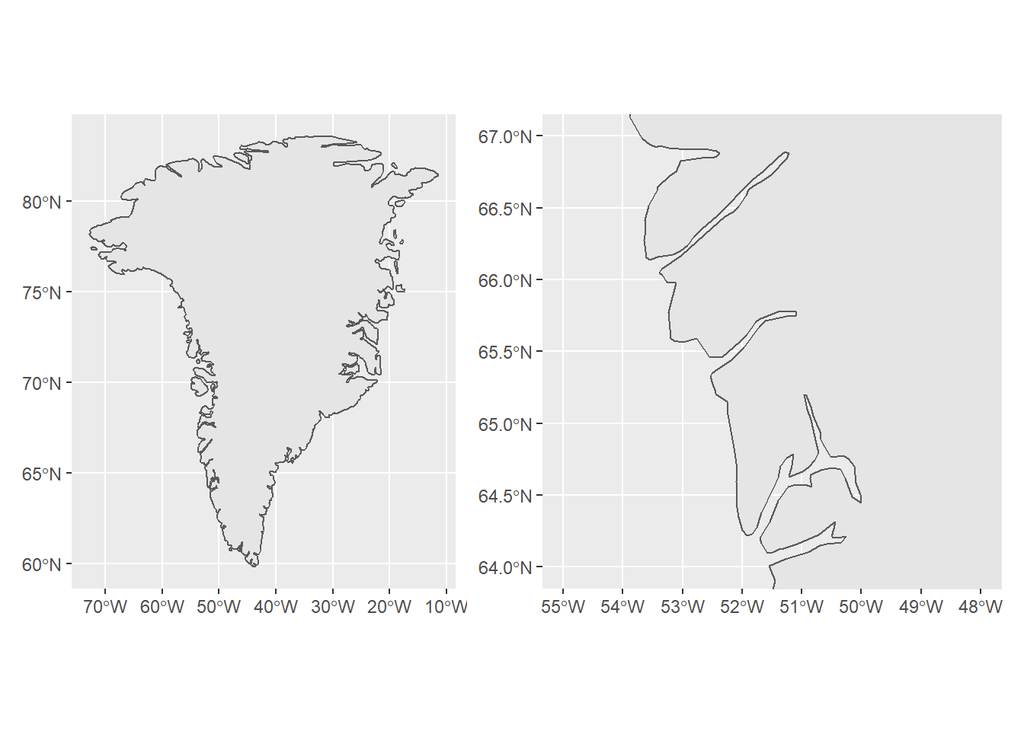

```r
kl_map <- ggplot(kl_sf) +
            geom_sf()

nuuk_map <- ggplot(kl_sf) +
              geom_sf() +
              coord_sf(xlim = nuuk.x, ylim = nuuk.y)

# Use patchwork package to show multiple plots side-by-side
library(patchwork)
kl_map + nuuk_map
```

- Install ‘rnaturalearth**hires**’ to get access higher resolution data.

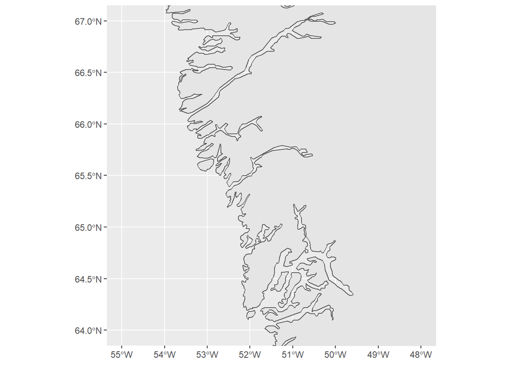

```r
# install.packages("devtools")
# devtools::install_github("ropensci/rnaturalearthhires")

kl_sf_high_res <- ne_countries(country = "greenland",
                               returnclass = "sf",
                               scale="large")

ggplot(kl_sf_high_res) +
  geom_sf() +
  coord_sf(xlim = nuuk.x, ylim = nuuk.y)
```

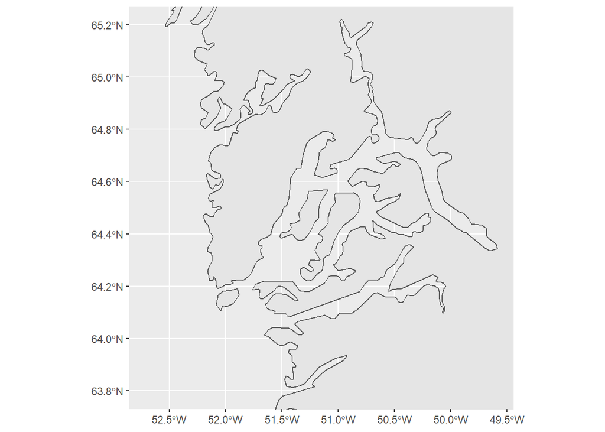

```r
ggplot(kl_sf_high_res) +
  geom_sf() +
  coord_sf(xlim = nuuk.close.x, ylim = nuuk.close.y)
```

## Add data on map [(13:26)](https://www.youtube.com/watch?v=Srg3DZu49S4&t=806s)

- Use the familiar geoms like `geom_point()` to add data on top of maps.

The package ‘maps’ contains the data set ‘world.cities’ with coordinates of cities around the world.

```r
library(maps)

kl_cities <-
  world.cities %>%
  as_tibble() %>%
  filter(country.etc == "Greenland") %>%
  arrange(-pop)

kl_cities
```

```
## # A tibble: 102 x 6
##    name       country.etc   pop   lat  long capital
##    <chr>      <chr>       <int> <dbl> <dbl>   <int>
##  1 Nuuk       Greenland   15243  64.2 -51.7       1
##  2 Sisimiut   Greenland    5203  66.9 -53.7       0
##  3 Ilulissat  Greenland    4352  69.2 -51.1       0
##  4 Qaqortoq   Greenland    3269  60.7 -46.0       0
##  5 Aasiaat    Greenland    3100  68.7 -52.8       0
##  6 Maniitsoq  Greenland    2846  65.4 -52.9       0
##  7 Paamiut    Greenland    1862  62.0 -49.7       0
##  8 Tasiilaq   Greenland    1833  65.6 -37.7       0
##  9 Narsaq     Greenland    1710  77.3 -68.9       0
## 10 Nanortalik Greenland    1488  60.2 -45.3       0
## # ... with 92 more rows
```

### Points [(14:29)](https://www.youtube.com/watch?v=Srg3DZu49S4&t=869s)

- The ggplot now uses two data sets, so we need to state which data set each layer uses.

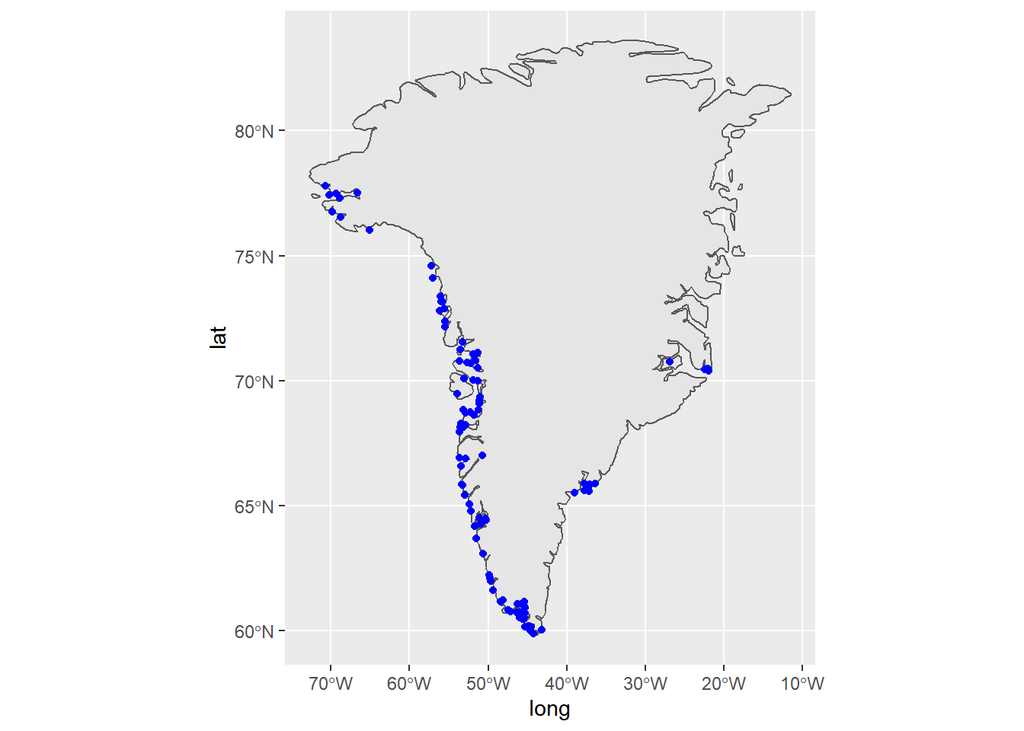

```r
ggplot() +
  geom_sf(data = kl_sf) +
  geom_point(data = kl_cities, aes(x = long, y = lat), color = "blue")
```

### Lables [(15:43)](https://www.youtube.com/watch?v=Srg3DZu49S4&t=943s)

- Add lables with `geom_text()` or `geom_label()`.

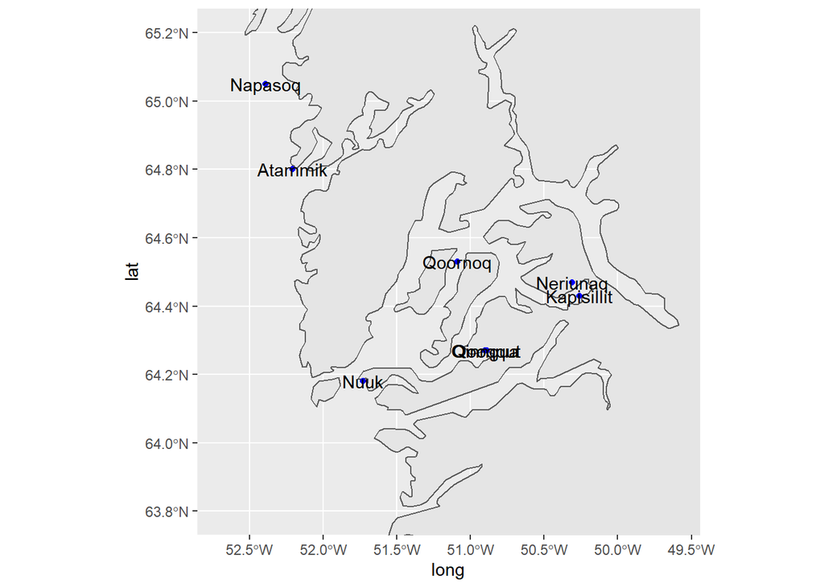

```r
ggplot(kl_sf_high_res) +
  geom_sf() +
  coord_sf(xlim = nuuk.close.x, ylim = nuuk.close.y) +
  geom_point(data = kl_cities, aes(x = long, y = lat), color = "blue") +
  geom_text(data = kl_cities, aes(x = long, y = lat, label = name))
```

## Projections [(16:54)](https://www.youtube.com/watch?v=Srg3DZu49S4&t=1014s)

Map projections are an eternal struggle. Things like geodectic datum, map projection, and parameters have to be considered. Together all of these can be boiled down into a *coordinate reference system* (CRS).

- The *coordinate reference system* (CRS) is stored in the sf data, and can be printed with `st_crs()`.

```r
st_crs(kl_sf)
```

```
## Coordinate Reference System:
##   User input: +proj=longlat +datum=WGS84 +no_defs +ellps=WGS84 +towgs84=0,0,0
##   wkt:
## BOUNDCRS[
##     SOURCECRS[
##         GEOGCRS["unknown",
##             DATUM["World Geodetic System 1984",
##                 ELLIPSOID["WGS 84",6378137,298.257223563,
##                     LENGTHUNIT["metre",1]],
##                 ID["EPSG",6326]],
##             PRIMEM["Greenwich",0,
##                 ANGLEUNIT["degree",0.0174532925199433],
##                 ID["EPSG",8901]],
##             CS[ellipsoidal,2],
##                 AXIS["longitude",east,
##                     ORDER[1],
##                     ANGLEUNIT["degree",0.0174532925199433,
##                         ID["EPSG",9122]]],
##                 AXIS["latitude",north,
##                     ORDER[2],
##                     ANGLEUNIT["degree",0.0174532925199433,
##                         ID["EPSG",9122]]]]],
##     TARGETCRS[
##         GEOGCRS["WGS 84",
##             DATUM["World Geodetic System 1984",
##                 ELLIPSOID["WGS 84",6378137,298.257223563,
##                     LENGTHUNIT["metre",1]]],
##             PRIMEM["Greenwich",0,
##                 ANGLEUNIT["degree",0.0174532925199433]],
##             CS[ellipsoidal,2],
##                 AXIS["latitude",north,
##                     ORDER[1],
##                     ANGLEUNIT["degree",0.0174532925199433]],
##                 AXIS["longitude",east,
##                     ORDER[2],
##                     ANGLEUNIT["degree",0.0174532925199433]],
##             ID["EPSG",4326]]],
##     ABRIDGEDTRANSFORMATION["Transformation from unknown to WGS84",
##         METHOD["Geocentric translations (geog2D domain)",
##             ID["EPSG",9603]],
##         PARAMETER["X-axis translation",0,
##             ID["EPSG",8605]],
##         PARAMETER["Y-axis translation",0,
##             ID["EPSG",8606]],
##         PARAMETER["Z-axis translation",0,
##             ID["EPSG",8607]]]]
```

- `coord_sf()` can change to any CRS found on https://epsg.io/.

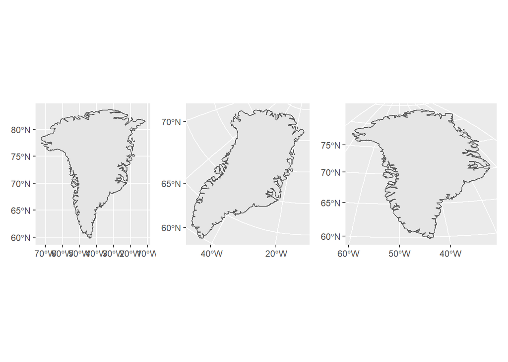

```r
kl_map_crs1 <-
  kl_map +
    coord_sf(crs = st_crs(3189)) # The number for CRS GR96 / UTM zone 29N

kl_map_crs2 <-
  kl_map +
    coord_sf(crs= "+proj=ortho +lat_0=15 +lon_0=-50")

kl_map + kl_map_crs1 + kl_map_crs2
```

## Raster maps [(21:01)](https://www.youtube.com/watch?v=Srg3DZu49S4&t=1261s)

Raster maps are based on images instead of vectors.

### GeoTiff [(21:19)](https://www.youtube.com/watch?v=Srg3DZu49S4&t=1279s)

- The package ‘stars’ can read GeoTiffs and `geom_stars()` can plot them as a standard ggplot layer.

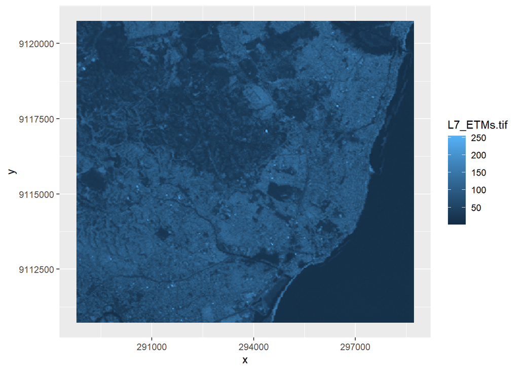

```r
library(stars)

tif <-
  system.file("tif/L7_ETMs.tif", package = "stars") %>%
  read_stars()

ggplot() +
  geom_stars(data = tif)
```

### ggmap [(22:48)](https://www.youtube.com/watch?v=Srg3DZu49S4&t=1368s)

- The package ‘ggmap’ can plot data from [Stamen](http://maps.stamen.com/) and other sources.
- Use `get_stamenmap()` to get the image data.
- Use `ggmap()` instead of `ggplot()`. You can add the familiar geoms to `ggmap()` just like it was `ggplot()`.

[www.bboxfinder.com](http://bboxfinder.com/#0.000000,0.000000,0.000000,0.000000) is useful for finding binding boxes.

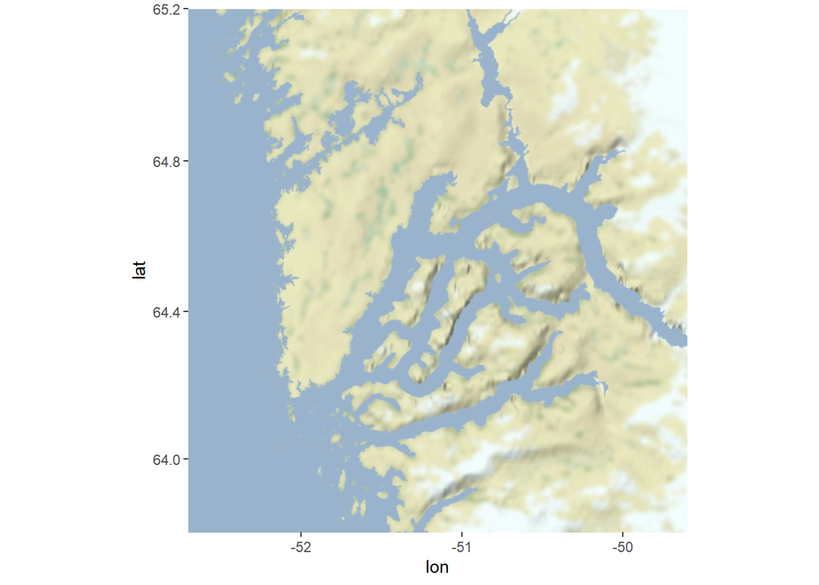

```r
library(ggmap)

nuuk_bounding_box <- c(left   = min(nuuk.close.x),
                       right  = max(nuuk.close.x),
                       bottom = min(nuuk.close.y),
                       top    = max(nuuk.close.y))

nuuk_stamen <- get_stamenmap(bbox = nuuk_bounding_box, zoom = 8)

ggmap(nuuk_stamen)
```

Different map types are available.

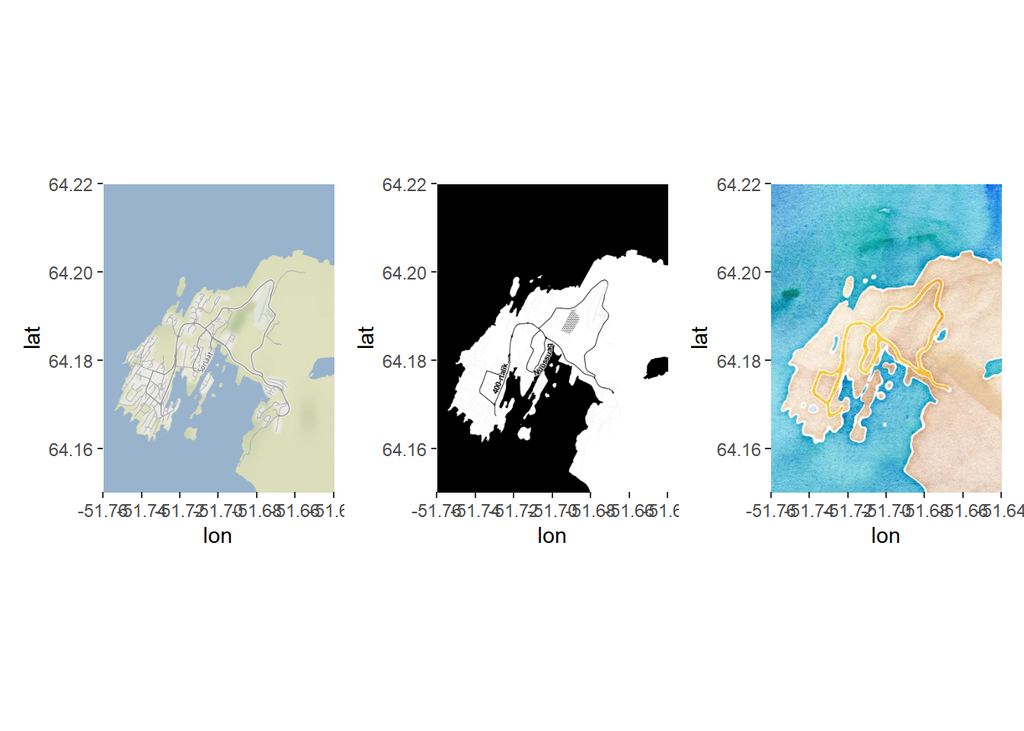

```r
nuuk_city_bb <- c(left   = -51.76,
                  right  = -51.64,
                  bottom =  64.15,
                  top    =  64.22)

city_zoom <- 12

p1 <- get_stamenmap(bbox = nuuk_city_bb, zoom = city_zoom) %>%
  ggmap()

p2 <- get_stamenmap(bbox = nuuk_city_bb, zoom = city_zoom, maptype="toner") %>%
  ggmap()

p3 <- get_stamenmap(bbox = nuuk_city_bb, zoom = city_zoom, maptype="watercolor") %>%
  ggmap()

p1 + p2 + p3
```

- ‘ggmap’ can also be used with google maps, but this requires a google account. (see more: [ggmap on GitHub](https://github.com/dkahle/ggmap)]